# A7: Clustering and Association Rule Mining

Jamison Orton

2026-07-21

# 1 Code Chunk 1: Load packages, prepare and inspect the data.

## 1.1 Part A: Package loading, data import, and transformation.

```r
# Import libraries
library(C50)
library(psych)
library(RWeka)
library(caret)
library(rminer)
library(matrixStats)
library(knitr)
library(arules)
library(tidyverse)
wmartvisits <- read.csv(file = "Walmart_visits_7trips.csv", stringsAsFactors = FALSE, fileEncoding = "latin1")

# Inspect the dataset
str(wmartvisits)
```

```
## 'data.frame':    12734 obs. of  9 variables:
##  $ TripType    : int  999 999 999 999 999 999 999 999 999 999 ...
##  $ DOW         : chr  "Friday" "Friday" "Friday" "Friday" ...
##  $ UniqueItems : int  1 2 1 1 2 1 1 1 1 1 ...
##  $ TotalQty    : int  0 1 0 0 3 0 0 0 1 0 ...
##  $ RtrnQty     : int  1 1 1 1 0 1 1 1 0 1 ...
##  $ NetQty      : int  -1 0 -1 -1 3 -1 -1 -1 1 -1 ...
##  $ UniqDepts   : int  1 1 1 1 2 1 1 1 1 1 ...
##  $ OneItemDepts: int  1 0 1 1 2 1 1 1 1 1 ...
##  $ RtrnDepts   : int  1 1 1 1 0 1 1 1 0 1 ...
```

```r
# Convert categorical variables to factors
wmartvisits <- wmartvisits %>%
  mutate(
    TripType = as.factor(TripType),
    DOW = as.factor(DOW)
  )

# Show summary of the mutated dataset
str(wmartvisits)
```

```
## 'data.frame':    12734 obs. of  9 variables:
##  $ TripType    : Factor w/ 7 levels "5","7","8","9",..: 7 7 7 7 7 7 7 7 7 7 ...
##  $ DOW         : Factor w/ 7 levels "Friday","Monday",..: 1 1 1 1 1 1 1 1 1 1 ...
##  $ UniqueItems : int  1 2 1 1 2 1 1 1 1 1 ...
##  $ TotalQty    : int  0 1 0 0 3 0 0 0 1 0 ...
##  $ RtrnQty     : int  1 1 1 1 0 1 1 1 0 1 ...
##  $ NetQty      : int  -1 0 -1 -1 3 -1 -1 -1 1 -1 ...
##  $ UniqDepts   : int  1 1 1 1 2 1 1 1 1 1 ...
##  $ OneItemDepts: int  1 0 1 1 2 1 1 1 1 1 ...
##  $ RtrnDepts   : int  1 1 1 1 0 1 1 1 0 1 ...
```

```r
summary(wmartvisits)
```

```
##  TripType          DOW        UniqueItems         TotalQty
##  5  :1106   Friday   :1851   Min.   :  1.000   Min.   :  0.000
##  7  :1305   Monday   :1765   1st Qu.:  1.000   1st Qu.:  1.000
##  8  :2808   Saturday :1923   Median :  2.000   Median :  3.000
##  9  :2046   Sunday   :2014   Mean   :  6.203   Mean   :  7.185
##  39 :2229   Thursday :1738   3rd Qu.:  7.000   3rd Qu.:  8.000
##  40 :1373   Tuesday  :1703   Max.   :113.000   Max.   :137.000
##  999:1867   Wednesday:1740
##     RtrnQty            NetQty          UniqDepts       OneItemDepts
##  Min.   : 0.0000   Min.   :-52.000   Min.   : 1.000   Min.   : 0.000
##  1st Qu.: 0.0000   1st Qu.:  1.000   1st Qu.: 1.000   1st Qu.: 1.000
##  Median : 0.0000   Median :  2.000   Median : 2.000   Median : 1.000
##  Mean   : 0.2431   Mean   :  6.942   Mean   : 3.194   Mean   : 1.918
##  3rd Qu.: 0.0000   3rd Qu.:  8.000   3rd Qu.: 4.000   3rd Qu.: 3.000
##  Max.   :52.0000   Max.   :137.000   Max.   :21.000   Max.   :12.000
##
##    RtrnDepts
##  Min.   : 0.0000
##  1st Qu.: 0.0000
##  Median : 0.0000
##  Mean   : 0.1756
##  3rd Qu.: 0.0000
##  Max.   :10.0000
##
```

## 1.2 Part B: Understand this data set using correlation analysis.

```r
# Select only numeric variables
wmartvisits_numeric <- wmartvisits %>%
  select(where(is.numeric))

# Inspect the numeric variables included
str(wmartvisits_numeric)
```

```
## 'data.frame':    12734 obs. of  7 variables:
##  $ UniqueItems : int  1 2 1 1 2 1 1 1 1 1 ...
##  $ TotalQty    : int  0 1 0 0 3 0 0 0 1 0 ...
##  $ RtrnQty     : int  1 1 1 1 0 1 1 1 0 1 ...
##  $ NetQty      : int  -1 0 -1 -1 3 -1 -1 -1 1 -1 ...
##  $ UniqDepts   : int  1 1 1 1 2 1 1 1 1 1 ...
##  $ OneItemDepts: int  1 0 1 1 2 1 1 1 1 1 ...
##  $ RtrnDepts   : int  1 1 1 1 0 1 1 1 0 1 ...
```

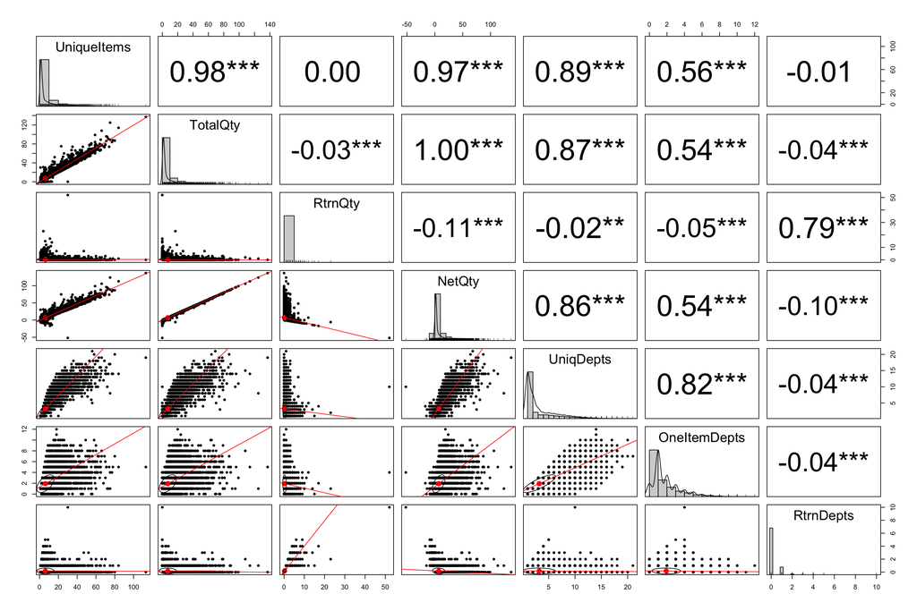

```r
# Show distributions and correlations
pairs.panels(
  wmartvisits_numeric,
  method = "pearson",
  hist.col = "lightgray",
  density = TRUE,
  ellipses = TRUE,
  lm = TRUE,
  stars = TRUE
)
```

## 1.3 Part C: Build a descriptive C5.0 decision tree using the entire data set, Prune the tree so that the number of tree leaves is smaller than 15, Plot the tree and show summary of the model to view tree rules and confusion matrix.

```r
# Confirm that the target variable is categorical
wmartvisits$TripType <- as.factor(wmartvisits$TripType)

# Confirm that day of week is categorical
wmartvisits$DOW <- as.factor(wmartvisits$DOW)

# Build a pruned C5.0 decision tree using the entire dataset
# A smaller CF value generally results in more aggressive pruning
wmart_c50 <- C50::C5.0(
  TripType ~ .,
  data = wmartvisits,
  trials = 1,
  rules = FALSE,
  control = C50::C5.0Control(
    CF = 0.01
  )
)

# Size of the pruned tree
wmart_c50$size
```

```
## [1] 5
```

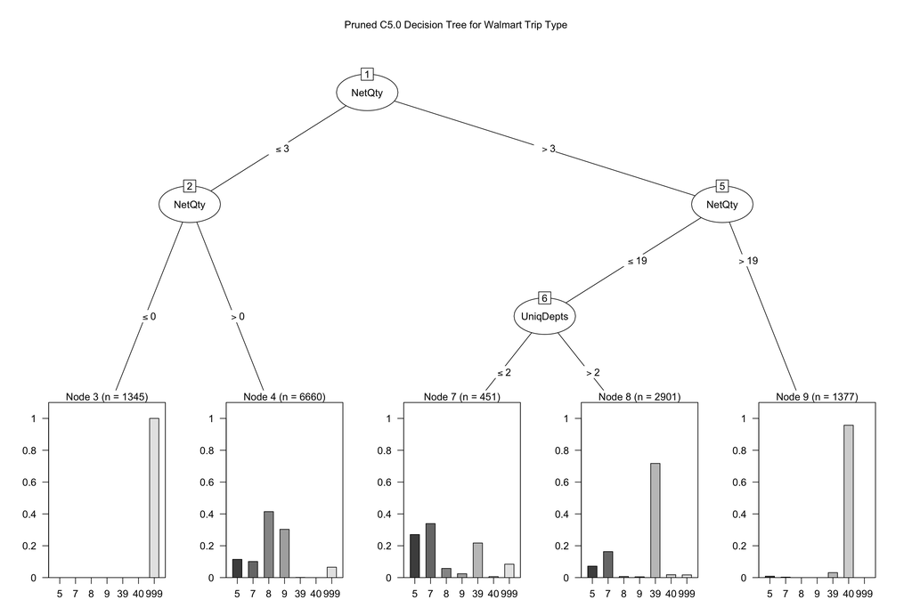

```r
# Plot the pruned decision tree
plot(
  wmart_c50,
  main = "Pruned C5.0 Decision Tree for Walmart Trip Type"
)
```

```r
# Display the tree rules, tree size, training errors,
# and confusion matrix
summary(wmart_c50)
```

```
##
## Call:
## C5.0.formula(formula = TripType ~ ., data = wmartvisits, trials = 1, rules
##  = FALSE, control = C50::C5.0Control(CF = 0.01))
##
##
## C5.0 [Release 2.07 GPL Edition]      Tue Jul 21 22:49:43 2026
## -------------------------------
##
## Class specified by attribute `outcome'
##
## Read 12734 cases (9 attributes) from undefined.data
##
## Decision tree:
##
## NetQty <= 3:
## :...NetQty <= 0: 999 (1345)
## :   NetQty > 0: 8 (6660/3899)
## NetQty > 3:
## :...NetQty > 19: 40 (1377/59)
##     NetQty <= 19:
##     :...UniqDepts <= 2: 7 (451/298)
##         UniqDepts > 2: 39 (2901/820)
##
##
## Evaluation on training data (12734 cases):
##
##      Decision Tree
##    ----------------
##    Size      Errors
##
##       5 5076(39.9%)   <<
##
##
##     (a)   (b)   (c)   (d)   (e)   (f)   (g)    <-classified as
##    ----  ----  ----  ----  ----  ----  ----
##           122   763         209    12          (a): class 5
##           153   674         474     4          (b): class 7
##            26  2761          21                (c): class 8
##            11  2020          15                (d): class 9
##            98     7        2081    43          (e): class 39
##             3                52  1318          (f): class 40
##            38   435          49        1345    (g): class 999
##
##
##  Attribute usage:
##
##  100.00% NetQty
##   26.32% UniqDepts
##
##
## Time: 0.0 secs
```

# 2 Code Chunk 2: Use SimpleKMeans clustering to understand visits.

## 2.1 Part A: Save the Number of Trip Types and Remove the Target Variable.

```r
# Save the number of unique TripType factor levels
TripType.levels <- nlevels(wmartvisits$TripType)

# Display the number of unique trip types
TripType.levels
```

```
## [1] 7
```

```r
# Create a copy of the data for clustering
wmartvisits_cluster <- wmartvisits

# Remove TripType because clustering is an unsupervised method
wmartvisits_cluster$TripType <- NULL

# Confirm that TripType was removed
str(wmartvisits_cluster)
```

```
## 'data.frame':    12734 obs. of  8 variables:
##  $ DOW         : Factor w/ 7 levels "Friday","Monday",..: 1 1 1 1 1 1 1 1 1 1 ...
##  $ UniqueItems : int  1 2 1 1 2 1 1 1 1 1 ...
##  $ TotalQty    : int  0 1 0 0 3 0 0 0 1 0 ...
##  $ RtrnQty     : int  1 1 1 1 0 1 1 1 0 1 ...
##  $ NetQty      : int  -1 0 -1 -1 3 -1 -1 -1 1 -1 ...
##  $ UniqDepts   : int  1 1 1 1 2 1 1 1 1 1 ...
##  $ OneItemDepts: int  1 0 1 1 2 1 1 1 1 1 ...
##  $ RtrnDepts   : int  1 1 1 1 0 1 1 1 0 1 ...
```

The variable TripType.levels stores the number of unique categories in the TripType factor. The TripType column was then removed from the clustering input because clustering is an unsupervised method and should not use the known target classification when creating the clusters.

## 2.2 Part B: K-Means Clustering with Random Initialization and Euclidean Distance.

```r
# Create clusters using:
# N = number of clusters
# V = display cluster standard deviations
# Random initialization and Euclidean distance are the defaults
cluster_random_euclidean <- RWeka::SimpleKMeans(
  wmartvisits_cluster,
  control = RWeka::Weka_control(
    N = TripType.levels,
    init = 0,
    S = 123,
    V = TRUE,
    A = "weka.core.EuclideanDistance"
  )
)

# Show clustering information, cluster sizes,
# standard deviations, and centroids
cluster_random_euclidean
```

```
##
## kMeans
## ======
##
## Number of iterations: 22
## Within cluster sum of squared errors: 4006.487727163814
##
## Initial starting points (random):
##
## Cluster 0: Sunday,2,2,0,2,1,0,0
## Cluster 1: Monday,1,1,0,1,1,1,0
## Cluster 2: Thursday,1,1,0,1,1,1,0
## Cluster 3: Thursday,13,15,0,15,8,6,0
## Cluster 4: Monday,24,24,0,24,13,7,0
## Cluster 5: Monday,57,66,0,66,18,8,0
## Cluster 6: Sunday,1,1,0,1,1,1,0
##
## Missing values globally replaced with mean/mode
##
## Final cluster centroids:
##                               Cluster#
## Attribute        Full Data           0           1           2           3           4           5           6
##                  (12734.0)    (1927.0)    (3104.0)    (2234.0)    (2077.0)     (866.0)     (235.0)    (2291.0)
## ==============================================================================================================
## DOW                 Sunday      Friday      Monday    Thursday    Saturday      Monday      Monday      Sunday
##   Friday       1851.0 ( 14%)1851.0 ( 96%)  0.0 (  0%)  0.0 (  0%)  0.0 (  0%)  0.0 (  0%)  0.0 (  0%)  0.0 (  0%)
##   Monday       1765.0 ( 13%)  0.0 (  0%)1285.0 ( 41%)  0.0 (  0%)  0.0 (  0%)384.0 ( 44%) 96.0 ( 40%)  0.0 (  0%)
##   Saturday     1923.0 ( 15%)  0.0 (  0%)  0.0 (  0%)  0.0 (  0%)1916.0 ( 92%)  0.0 (  0%)  7.0 (  2%)  0.0 (  0%)
##   Sunday       2014.0 ( 15%)  0.0 (  0%)  0.0 (  0%)  0.0 (  0%)  0.0 (  0%)  0.0 (  0%)  2.0 (  0%)2012.0 ( 87%)
##   Thursday     1738.0 ( 13%)  0.0 (  0%)  0.0 (  0%)1735.0 ( 77%)  0.0 (  0%)  0.0 (  0%)  3.0 (  1%)  0.0 (  0%)
##   Tuesday      1703.0 ( 13%) 39.0 (  2%)901.0 ( 29%)234.0 ( 10%) 77.0 (  3%)238.0 ( 27%) 67.0 ( 28%)147.0 (  6%)
##   Wednesday    1740.0 ( 13%) 37.0 (  1%)918.0 ( 29%)265.0 ( 11%) 84.0 (  4%)244.0 ( 28%) 60.0 ( 25%)132.0 (  5%)
##
## UniqueItems         6.2033      5.8199      1.9343      4.7278      6.2951     13.0727     38.0894      7.7979
##                  +/-9.1936   +/-8.4328   +/-1.6803    +/-7.294   +/-8.5784   +/-5.9062  +/-14.9096  +/-10.0086
##
## TotalQty            7.1849      6.8282      2.0319      5.4593      7.2109     15.4157     45.4043      9.0938
##                 +/-11.2831  +/-10.4491   +/-2.3337   +/-9.2608  +/-10.4183   +/-7.5406  +/-18.6303  +/-12.3091
##
## RtrnQty             0.2431      0.2226      0.2851      0.2265      0.2537      0.1952      0.2894      0.2235
##                  +/-0.9149   +/-0.7102   +/-0.8836   +/-0.6842   +/-0.8854   +/-1.8784   +/-0.6281   +/-0.7918
##
## NetQty              6.9417      6.6056      1.7468      5.2328      6.9571     15.2206     45.1149      8.8704
##                 +/-11.3513   +/-10.516   +/-2.5735   +/-9.3021  +/-10.5073   +/-7.8672  +/-18.5564  +/-12.3589
##
## UniqDepts           3.1938      3.0187      1.3576      2.7471      3.3255      6.9469     12.1787      3.8049
##                  +/-3.0952   +/-2.9162   +/-0.6786   +/-2.4865   +/-3.0283   +/-1.6759     +/-2.63   +/-3.2543
##
## OneItemDepts        1.9179      1.7987      0.9478      1.8671      2.0448      4.0704           5      2.1371
##                  +/-1.6439   +/-1.6093   +/-0.6102   +/-1.3671   +/-1.6153   +/-1.4611   +/-2.1741   +/-1.6693
##
## RtrnDepts           0.1756      0.1624      0.2001      0.1795      0.1772      0.1132       0.234      0.1659
##                  +/-0.4553   +/-0.4276   +/-0.4311   +/-0.4612   +/-0.4772   +/-0.4984    +/-0.472   +/-0.4621
```

## 2.3 Part C: K-Means++ Initialization and Euclidean Distance.

```r
# Create clusters using:
# P = K-means++ initialization
# Euclidean distance remains the default
cluster_kmeanspp_euclidean <- RWeka::SimpleKMeans(
  wmartvisits_cluster,
  control = RWeka::Weka_control(
    N = TripType.levels,
    init = 1,
    S = 123,
    V = TRUE,
    A = "weka.core.EuclideanDistance"
  )
)

# Show clustering information, cluster sizes,
# standard deviations, and centroids
cluster_kmeanspp_euclidean
```

```
##
## kMeans
## ======
##
## Number of iterations: 8
## Within cluster sum of squared errors: 2419.143417471525
##
## Initial starting points (k-means++):
##
## Cluster 0: Sunday,2,2,0,2,1,0,0
## Cluster 1: Tuesday,29,36,2,34,10,5,1
## Cluster 2: Saturday,3,3,0,3,2,1,0
## Cluster 3: Wednesday,1,1,0,1,1,1,0
## Cluster 4: Wednesday,27,28,0,28,10,4,0
## Cluster 5: Thursday,1,3,0,3,1,1,0
## Cluster 6: Friday,1,1,0,1,1,1,0
##
## Missing values globally replaced with mean/mode
##
## Final cluster centroids:
##                               Cluster#
## Attribute        Full Data           0           1           2           3           4           5           6
##                  (12734.0)    (2224.0)    (1802.0)    (1943.0)    (2291.0)     (629.0)    (1964.0)    (1881.0)
## ==============================================================================================================
## DOW                 Sunday      Sunday     Tuesday    Saturday   Wednesday   Wednesday    Thursday      Friday
##   Friday       1851.0 ( 14%)  0.0 (  0%)  0.0 (  0%)  0.0 (  0%)  0.0 (  0%)  0.0 (  0%)  0.0 (  0%)1851.0 ( 98%)
##   Monday       1765.0 ( 13%)210.0 (  9%) 99.0 (  5%) 20.0 (  1%)873.0 ( 38%)307.0 ( 48%)226.0 ( 11%) 30.0 (  1%)
##   Saturday     1923.0 ( 15%)  0.0 (  0%)  0.0 (  0%)1923.0 ( 98%)  0.0 (  0%)  0.0 (  0%)  0.0 (  0%)  0.0 (  0%)
##   Sunday       2014.0 ( 15%)2014.0 ( 90%)  0.0 (  0%)  0.0 (  0%)  0.0 (  0%)  0.0 (  0%)  0.0 (  0%)  0.0 (  0%)
##   Thursday     1738.0 ( 13%)  0.0 (  0%)  0.0 (  0%)  0.0 (  0%)  0.0 (  0%)  0.0 (  0%)1738.0 ( 88%)  0.0 (  0%)
##   Tuesday      1703.0 ( 13%)  0.0 (  0%)1703.0 ( 94%)  0.0 (  0%)  0.0 (  0%)  0.0 (  0%)  0.0 (  0%)  0.0 (  0%)
##   Wednesday    1740.0 ( 13%)  0.0 (  0%)  0.0 (  0%)  0.0 (  0%)1418.0 ( 61%)322.0 ( 51%)  0.0 (  0%)  0.0 (  0%)
##
## UniqueItems         6.2033      7.8674      5.3779      6.7921      2.1907     20.0382      5.1334      5.7964
##                  +/-9.1936  +/-10.3373   +/-7.9721    +/-9.712   +/-2.0095  +/-12.4682   +/-8.1229   +/-8.5287
##
## TotalQty            7.1849      9.1497      6.1632      7.8338       2.323     23.7886      5.9807      6.7969
##                 +/-11.2831   +/-12.588   +/-9.7214  +/-11.8064   +/-2.6488  +/-15.3435  +/-10.3917  +/-10.5686
##
## RtrnQty             0.2431      0.2347      0.2469       0.262      0.2894      0.1876      0.2174       0.219
##                  +/-0.9149   +/-0.8114   +/-1.4347   +/-0.8887   +/-0.9034   +/-0.7047   +/-0.6456   +/-0.7085
##
## NetQty              6.9417       8.915      5.9162      7.5718      2.0336      23.601      5.7632      6.5779
##                 +/-11.3513   +/-12.641    +/-9.904  +/-11.8797   +/-2.8738  +/-15.2684  +/-10.4073  +/-10.6374
##
## UniqDepts           3.1938      3.8282      2.9595      3.4071      1.5417      8.6296      2.8345      3.0175
##                  +/-3.0952   +/-3.3432    +/-2.749   +/-3.2491   +/-0.9115   +/-2.6598   +/-2.6777   +/-2.9511
##
## OneItemDepts        1.9179      2.1623      1.8851      1.9799      1.1021      4.4356      1.8544      1.8139
##                  +/-1.6439   +/-1.7071   +/-1.5907   +/-1.6688   +/-0.7512   +/-1.6989   +/-1.4663   +/-1.6241
##
## RtrnDepts           0.1756      0.1736      0.1582      0.1822      0.2104      0.1415      0.1726        0.16
##                  +/-0.4553   +/-0.4738   +/-0.4653   +/-0.4736   +/-0.4713   +/-0.3752   +/-0.4368   +/-0.4245
```

## 2.4 Part D: K-Means++ Initialization and Manhattan Distance.

```r
# Cluster visits using K-means++ initialization
# and Manhattan distance
cluster_kmeanspp_manhattan <- RWeka::SimpleKMeans(
  wmartvisits_cluster,
  control = RWeka::Weka_control(
    N = TripType.levels,
    init = 1,
    S = 123,
    V = TRUE,
    A = "weka.core.ManhattanDistance"
  )
)

# Show cluster sizes, standard deviations, and centroids
cluster_kmeanspp_manhattan
```

```
##
## kMeans
## ======
##
## Number of iterations: 7
## Sum of within cluster distances: 7871.722526729827
##
## Initial starting points (k-means++):
##
## Cluster 0: Sunday,2,2,0,2,1,0,0
## Cluster 1: Monday,20,21,0,21,8,3,0
## Cluster 2: Friday,1,1,0,1,1,1,0
## Cluster 3: Wednesday,2,2,0,2,2,2,0
## Cluster 4: Monday,32,38,1,37,14,5,1
## Cluster 5: Friday,9,9,0,9,5,3,0
## Cluster 6: Monday,2,2,0,2,1,0,0
##
## Missing values globally replaced with mean/mode
##
## Final cluster centroids:
##                               Cluster#
## Attribute        Full Data           0           1           2           3           4           5           6
##                  (12734.0)    (2092.0)     (861.0)    (2923.0)    (2729.0)     (826.0)    (1315.0)    (1988.0)
## ==============================================================================================================
## DOW                 Sunday      Sunday      Monday      Friday   Wednesday      Sunday      Friday      Monday
##   Friday       1851.0 ( 14%)  0.0 (  0%)  0.0 (  0%)1265.0 ( 43%)  0.0 (  0%)  0.0 (  0%)586.0 ( 44%)  0.0 (  0%)
##   Monday       1765.0 ( 13%)  0.0 (  0%)446.0 ( 51%)  0.0 (  0%)  0.0 (  0%)  0.0 (  0%)  0.0 (  0%)1319.0 ( 66%)
##   Saturday     1923.0 ( 15%)195.0 (  9%)174.0 ( 20%)566.0 ( 19%)339.0 ( 12%)169.0 ( 20%)260.0 ( 19%)220.0 ( 11%)
##   Sunday       2014.0 ( 15%)1576.0 ( 75%)  0.0 (  0%)  0.0 (  0%)  0.0 (  0%)438.0 ( 53%)  0.0 (  0%)  0.0 (  0%)
##   Thursday     1738.0 ( 13%)160.0 (  7%)112.0 ( 13%)545.0 ( 18%)367.0 ( 13%) 96.0 ( 11%)232.0 ( 17%)226.0 ( 11%)
##   Tuesday      1703.0 ( 13%)161.0 (  7%)129.0 ( 14%)547.0 ( 18%)320.0 ( 11%) 86.0 ( 10%)237.0 ( 18%)223.0 ( 11%)
##   Wednesday    1740.0 ( 13%)  0.0 (  0%)  0.0 (  0%)  0.0 (  0%)1703.0 ( 62%) 37.0 (  4%)  0.0 (  0%)  0.0 (  0%)
##
## UniqueItems              2           3          15           1           2          25           9           2
##                  +/-9.1936   +/-3.0227   +/-9.6194   +/-0.9639   +/-5.1122  +/-13.5113   +/-8.5345    +/-1.678
##
## TotalQty                 3           3          18           1           2          30          10           2
##                 +/-11.2831   +/-3.9736  +/-11.7319   +/-1.4784   +/-6.3662  +/-17.1444   +/-10.838   +/-2.3224
##
## RtrnQty                  0           0           0           0           0           0           0           0
##                  +/-0.9149   +/-0.9767   +/-1.8588   +/-0.8034   +/-0.8606   +/-0.6101   +/-0.5507   +/-0.7213
##
## NetQty                   2           3          18           1           2          30          10           2
##                 +/-11.3513   +/-4.2124  +/-11.9309    +/-1.833   +/-6.4359  +/-17.0653  +/-10.8372   +/-2.5032
##
## UniqDepts                2           2           8           1           2          10           5           1
##                  +/-3.0952   +/-1.3247   +/-2.2276   +/-0.4242   +/-1.9708   +/-2.6364   +/-2.2634   +/-0.8419
##
## OneItemDepts             1           1           4           1           2           5           3           1
##                  +/-1.6439   +/-0.9864   +/-1.8039   +/-0.4391    +/-1.195   +/-1.8839    +/-1.549   +/-0.8453
##
## RtrnDepts                0           0           0           0           0           0           0           0
##                  +/-0.4553   +/-0.4944   +/-0.5056   +/-0.4492   +/-0.4746   +/-0.4324    +/-0.402   +/-0.3983
```

This model continues to use K-means++ initialization and keeps the number of clusters equal to TripType.levels. However, Manhattan distance replaces Euclidean distance. When Manhattan distance is used, Weka calculates cluster centers using component-wise medians rather than component-wise means.

## 2.5 Part E: Alternative Clustering Configuration.

```r
# Increase the number of clusters by one
alternative_cluster_count <- TripType.levels + 1

# Create an alternative clustering model using:
# Random initial assignment
# Manhattan distance
# One additional cluster
cluster_alternative <- RWeka::SimpleKMeans(
  wmartvisits_cluster,
  control = RWeka::Weka_control(
    N = alternative_cluster_count,
    V = TRUE,
    S = 456,
    A = "weka.core.ManhattanDistance"
  )
)

# Show the selected number of clusters
alternative_cluster_count
```

```
## [1] 8
```

```r
# Show clustering information, cluster sizes,
# standard deviations, and centroids
cluster_alternative
```

```
##
## kMeans
## ======
##
## Number of iterations: 8
## Sum of within cluster distances: 5249.1348427997855
##
## Initial starting points (random):
##
## Cluster 0: Tuesday,1,1,0,1,1,1,0
## Cluster 1: Saturday,3,3,0,3,1,0,0
## Cluster 2: Saturday,6,6,0,6,3,1,0
## Cluster 3: Friday,3,3,0,3,3,3,0
## Cluster 4: Thursday,1,1,0,1,1,1,0
## Cluster 5: Sunday,18,23,0,23,9,5,0
## Cluster 6: Wednesday,2,2,0,2,2,2,0
## Cluster 7: Friday,8,8,0,8,6,4,0
##
## Missing values globally replaced with mean/mode
##
## Final cluster centroids:
##                               Cluster#
## Attribute        Full Data           0           1           2           3           4           5           6           7
##                  (12734.0)    (1708.0)    (1853.0)     (841.0)    (1666.0)    (1894.0)    (2415.0)    (1740.0)     (617.0)
## ==========================================================================================================================
## DOW                 Sunday     Tuesday    Saturday    Saturday      Friday    Thursday      Sunday   Wednesday      Friday
##   Friday       1851.0 ( 14%)  0.0 (  0%)  0.0 (  0%)  0.0 (  0%)1469.0 ( 88%)  0.0 (  0%)  0.0 (  0%)  0.0 (  0%)382.0 ( 61%)
##   Monday       1765.0 ( 13%)  5.0 (  0%)535.0 ( 28%)236.0 ( 28%)197.0 ( 11%)156.0 (  8%)401.0 ( 16%)  0.0 (  0%)235.0 ( 38%)
##   Saturday     1923.0 ( 15%)  0.0 (  0%)1318.0 ( 71%)605.0 ( 71%)  0.0 (  0%)  0.0 (  0%)  0.0 (  0%)  0.0 (  0%)  0.0 (  0%)
##   Sunday       2014.0 ( 15%)  0.0 (  0%)  0.0 (  0%)  0.0 (  0%)  0.0 (  0%)  0.0 (  0%)2014.0 ( 83%)  0.0 (  0%)  0.0 (  0%)
##   Thursday     1738.0 ( 13%)  0.0 (  0%)  0.0 (  0%)  0.0 (  0%)  0.0 (  0%)1738.0 ( 91%)  0.0 (  0%)  0.0 (  0%)  0.0 (  0%)
##   Tuesday      1703.0 ( 13%)1703.0 ( 99%)  0.0 (  0%)  0.0 (  0%)  0.0 (  0%)  0.0 (  0%)  0.0 (  0%)  0.0 (  0%)  0.0 (  0%)
##   Wednesday    1740.0 ( 13%)  0.0 (  0%)  0.0 (  0%)  0.0 (  0%)  0.0 (  0%)  0.0 (  0%)  0.0 (  0%)1740.0 (100%)  0.0 (  0%)
##
## UniqueItems              2           2           1          12           2           2           3           2          19
##                  +/-9.1936   +/-8.1746   +/-1.3446  +/-10.7354   +/-1.9395   +/-8.2195   +/-9.9899   +/-7.8033  +/-12.6124
##
## TotalQty                 3           2           1          15           2           3           3           2          22
##                 +/-11.2831   +/-9.9715   +/-2.0023  +/-13.1835   +/-2.7014   +/-10.526  +/-12.1223   +/-9.5957  +/-15.3884
##
## RtrnQty                  0           0           0           0           0           0           0           0           0
##                  +/-0.9149   +/-1.4943   +/-0.9231   +/-0.5976    +/-0.752   +/-0.6615   +/-0.8093   +/-0.9047   +/-0.5209
##
## NetQty                   2           2           1          15           2           3           3           2          22
##                 +/-11.3513  +/-10.1724   +/-2.3516  +/-13.1558   +/-2.9074  +/-10.5451  +/-12.1685    +/-9.642  +/-15.3244
##
## UniqDepts                2           2           1           6           1           2           2           2           8
##                  +/-3.0952   +/-2.8241    +/-0.672    +/-2.668   +/-0.9507   +/-2.7208   +/-3.2218   +/-2.8278   +/-2.7828
##
## OneItemDepts             1           1           1           3           1           1           2           1           4
##                  +/-1.6439   +/-1.6208   +/-0.6282    +/-1.719   +/-0.8752   +/-1.5174   +/-1.6105    +/-1.554   +/-1.9476
##
## RtrnDepts                0           0           0           0           0           0           0           0           0
##                  +/-0.4553   +/-0.4833   +/-0.4809   +/-0.4324   +/-0.4251   +/-0.4364    +/-0.476   +/-0.4509   +/-0.3709
```

The alternative model uses TripType.levels + 1 clusters, random initial cluster assignment, and Manhattan distance. Increasing the cluster count allows the algorithm to create a more detailed segmentation of the Walmart visits. The resulting cluster sizes, within-cluster standard deviations, and centroids can be compared with the previous models to determine how the selected configuration affects the clustering results.

# 3 Code Chunk 3 - Market Basket Analysis with the Walmart dept baskets.

## 3.1 Part A: Import the Walmart Basket Transactions.

```r
# Import the long-format basket data as a sparse transactions object
Dept_baskets <- read.transactions("Walmart_baskets_1week.csv", format="single", sep = ",", header = TRUE, cols=c("VisitNumber","DepartmentDescription"))

# Show a summary of the transaction data
summary(Dept_baskets)
```

```
## transactions as itemMatrix in sparse format with
##  2000 rows (elements/itemsets/transactions) and
##  66 columns (items) and a density of 0.0507803
##
## most frequent items:
##         DSD GROCERY   GROCERY DRY GOODS IMPULSE MERCHANDISE             PRODUCE
##                 612                 433                 414                 386
##               DAIRY             (Other)
##                 384                4474
##
## element (itemset/transaction) length distribution:
## sizes
##   1   2   3   4   5   6   7   8   9  10  11  12  13  14  15  16  17
## 693 372 246 173 127 112  70  67  49  34  20   9  12   9   2   3   2
##
##    Min. 1st Qu.  Median    Mean 3rd Qu.    Max.
##   1.000   1.000   2.000   3.352   5.000  17.000
##
## includes extended item information - examples:
##        labels
## 1  1-HR PHOTO
## 2 ACCESSORIES
## 3  AUTOMOTIVE
##
## includes extended transaction information - examples:
##   transactionID
## 1         10009
## 2         10034
## 3         10051
```

## 3.2 Part B: Inspect the First 15 Transactions.

```r
# Inspect the first 15 shopping transactions
inspect(Dept_baskets[1:15])
```

```
##      items                         transactionID
## [1]  {IMPULSE MERCHANDISE}                 10009
## [2]  {CANDY, TOBACCO, COOKIES,
##       HOME MANAGEMENT,
##       JEWELRY AND SUNGLASSES,
##       MENS WEAR}                           10034
## [3]  {GIRLS WEAR, 4-6X  AND 7-14,
##       GROCERY DRY GOODS,
##       IMPULSE MERCHANDISE,
##       PERSONAL CARE}                       10051
## [4]  {OTHER DEPARTMENTS}                   10118
## [5]  {FINANCIAL SERVICES}                  10167
## [6]  {DAIRY,
##       DSD GROCERY,
##       FROZEN FOODS,
##       GROCERY DRY GOODS,
##       MEAT - FRESH & FROZEN,
##       PERSONAL CARE,
##       PRE PACKED DELI,
##       SLEEPWEAR/FOUNDATIONS}               10178
## [7]  {PHARMACY OTC}                        10191
## [8]  {FINANCIAL SERVICES}                  10206
## [9]  {INFANT CONSUMABLE HARDLINES}         1022
## [10] {CELEBRATION,
##       FABRICS AND CRAFTS,
##       OFFICE SUPPLIES,
##       TOYS}                                10250
## [11] {PHARMACY OTC}                        10272
## [12] {FABRICS AND CRAFTS,
##       GROCERY DRY GOODS,
##       PRODUCE}                             10273
## [13] {SERVICE DELI}                        1029
## [14] {BEAUTY,
##       DSD GROCERY,
##       GROCERY DRY GOODS,
##       HOME DECOR,
##       HOME MANAGEMENT,
##       HOUSEHOLD CHEMICALS/SUPP,
##       HOUSEHOLD PAPER GOODS,
##       LAWN AND GARDEN,
##       PAINT AND ACCESSORIES,
##       PERSONAL CARE,
##       PETS AND SUPPLIES}                   10296
## [15] {BEAUTY}                              10302
```

## 3.3 Part C: Plot the 15 Most Frequent Items.

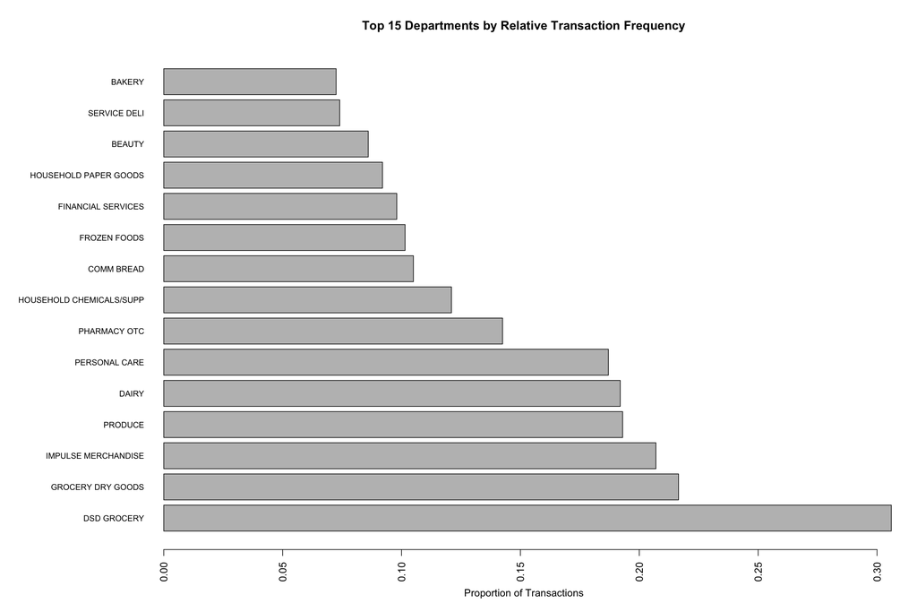

```r
# Plot the 15 departments with the highest transaction frequencies
itemFrequencyPlot(
  Dept_baskets,
  topN = 15,
  type = "relative",
  decreasing = TRUE,
  horiz = TRUE,
  main = "Top 15 Departments by Relative Transaction Frequency",
  xlab = "Proportion of Transactions",
  cex.names = 0.8
)
```

The plot displays the 15 departments appearing in the greatest percentage of Walmart transactions. Setting type = “relative” expresses item frequency relative to the total number of transactions rather than as a raw transaction count.

## 3.4 Part D: Association Rule Mining.

### 3.4.1 Part D.i: Generate Approximately 50–100 Association Rules.

```r
# Generate approximately 50 to 100 association rules
rules_50_100 <- apriori(
  Dept_baskets,
  parameter = list(
    support = 0.02,
    confidence = 0.85,
    minlen = 2,
    maxlen = 4,
    target = "rules"
  )
)
```

```
## Apriori
##
## Parameter specification:
##  confidence minval smax arem  aval originalSupport maxtime support minlen
##        0.85    0.1    1 none FALSE            TRUE       5    0.02      2
##  maxlen target  ext
##       4  rules TRUE
##
## Algorithmic control:
##  filter tree heap memopt load sort verbose
##     0.1 TRUE TRUE  FALSE TRUE    2    TRUE
##
## Absolute minimum support count: 40
##
## set item appearances ...[0 item(s)] done [0.00s].
## set transactions ...[66 item(s), 2000 transaction(s)] done [0.00s].
## sorting and recoding items ... [38 item(s)] done [0.00s].
## creating transaction tree ... done [0.00s].
## checking subsets of size 1 2 3 4
```

```
##  done [0.00s].
## writing ... [78 rule(s)] done [0.00s].
## creating S4 object  ... done [0.00s].
```

```r
# Display the number of generated rules
length(rules_50_100)
```

```
## [1] 78
```

```r
# Sort the rules from highest to lowest lift
rules_50_100_lift <- sort(
  rules_50_100,
  by = "lift",
  decreasing = TRUE
)

# Show the rules in descending order of lift
inspect(rules_50_100_lift)
```

```
##      lhs                           rhs                 support confidence coverage     lift count
## [1]  {GROCERY DRY GOODS,
##       PRE PACKED DELI,
##       PRODUCE}                  => {DAIRY}              0.0255  0.9622642   0.0265 5.011792    51
## [2]  {COMM BREAD,
##       FROZEN FOODS,
##       PRODUCE}                  => {DAIRY}              0.0230  0.9583333   0.0240 4.991319    46
## [3]  {FROZEN FOODS,
##       GROCERY DRY GOODS,
##       PRODUCE}                  => {DAIRY}              0.0350  0.9333333   0.0375 4.861111    70
## [4]  {FROZEN FOODS,
##       MEAT - FRESH & FROZEN}    => {DAIRY}              0.0215  0.9148936   0.0235 4.765071    43
## [5]  {PRE PACKED DELI,
##       PRODUCE}                  => {DAIRY}              0.0320  0.9142857   0.0350 4.761905    64
## [6]  {COMM BREAD,
##       DSD GROCERY,
##       MEAT - FRESH & FROZEN}    => {DAIRY}              0.0240  0.9056604   0.0265 4.716981    48
## [7]  {COMM BREAD,
##       GROCERY DRY GOODS,
##       PRE PACKED DELI}          => {DAIRY}              0.0225  0.9000000   0.0250 4.687500    45
## [8]  {DSD GROCERY,
##       PRE PACKED DELI,
##       PRODUCE}                  => {DAIRY}              0.0265  0.8983051   0.0295 4.678672    53
## [9]  {MEAT - FRESH & FROZEN,
##       PRE PACKED DELI}          => {DAIRY}              0.0220  0.8979592   0.0245 4.676871    44
## [10] {DSD GROCERY,
##       GROCERY DRY GOODS,
##       PRE PACKED DELI}          => {DAIRY}              0.0295  0.8939394   0.0330 4.655934    59
## [11] {GROCERY DRY GOODS,
##       PRE PACKED DELI}          => {DAIRY}              0.0345  0.8846154   0.0390 4.607372    69
## [12] {COMM BREAD,
##       FROZEN FOODS,
##       GROCERY DRY GOODS}        => {DAIRY}              0.0295  0.8805970   0.0335 4.586443    59
## [13] {COMM BREAD,
##       MEAT - FRESH & FROZEN,
##       PRODUCE}                  => {DAIRY}              0.0215  0.8775510   0.0245 4.570578    43
## [14] {DSD GROCERY,
##       GROCERY DRY GOODS,
##       MEAT - FRESH & FROZEN}    => {DAIRY}              0.0310  0.8732394   0.0355 4.548122    62
## [15] {COMM BREAD,
```

[output cut: 155 more lines]

```
##       DAIRY,
##       GROCERY DRY GOODS}        => {DSD GROCERY}        0.0485  0.8660714   0.0560 2.830299    97
## [74] {DAIRY,
##       GROCERY DRY GOODS,
##       MEAT - FRESH & FROZEN}    => {DSD GROCERY}        0.0310  0.8611111   0.0360 2.814089    62
## [75] {FROZEN FOODS,
##       GROCERY DRY GOODS}        => {DSD GROCERY}        0.0545  0.8582677   0.0635 2.804796   109
## [76] {DAIRY,
##       GROCERY DRY GOODS,
##       PRE PACKED DELI}          => {DSD GROCERY}        0.0295  0.8550725   0.0345 2.794354    59
## [77] {DAIRY,
##       GROCERY DRY GOODS,
##       HOUSEHOLD CHEMICALS/SUPP} => {DSD GROCERY}        0.0295  0.8550725   0.0345 2.794354    59
## [78] {DAIRY,
##       HOUSEHOLD PAPER GOODS}    => {DSD GROCERY}        0.0380  0.8539326   0.0445 2.790629    76
```

The first association-rule model uses a minimum support threshold of 0.02 and a minimum confidence threshold of 0.85. A support value of 0.02 requires a rule to occur in at least 2% of the Walmart transactions. A confidence value of 0.85 requires the right-hand-side item to appear in at least 85% of transactions containing the left-hand-side item or items.

The rules are sorted in descending order of lift. A lift value greater than 1 indicates that the items occur together more frequently than would be expected if they were independent.

### 3.4.2 Part D.ii: Generate Approximately 100–200 Association Rules.

```r
# Generate approximately 100 to 200 association rules
rules_100_200 <- apriori(
  Dept_baskets,
  parameter = list(
    support = 0.02,
    confidence = 0.80,
    minlen = 2,
    maxlen = 6,
    target = "rules"
  )
)
```

```
## Apriori
##
## Parameter specification:
##  confidence minval smax arem  aval originalSupport maxtime support minlen
##         0.8    0.1    1 none FALSE            TRUE       5    0.02      2
##  maxlen target  ext
##       6  rules TRUE
##
## Algorithmic control:
##  filter tree heap memopt load sort verbose
##     0.1 TRUE TRUE  FALSE TRUE    2    TRUE
##
## Absolute minimum support count: 40
##
## set item appearances ...[0 item(s)] done [0.00s].
## set transactions ...[66 item(s), 2000 transaction(s)] done [0.01s].
## sorting and recoding items ... [38 item(s)] done [0.00s].
## creating transaction tree ... done [0.00s].
## checking subsets of size 1 2 3 4 5 6
```

```
##  done [0.00s].
## writing ... [185 rule(s)] done [0.00s].
## creating S4 object  ... done [0.00s].
```

```r
# Display the number of generated rules
length(rules_100_200)
```

```
## [1] 185
```

```r
# Sort the rules from highest to lowest lift
rules_100_200_lift <- sort(
  rules_100_200,
  by = "lift",
  decreasing = TRUE
)

# Show the rules in descending order of lift
inspect(rules_100_200_lift)
```

```
##       lhs                            rhs                 support confidence coverage     lift count
## [1]   {COMM BREAD,
##        FROZEN FOODS,
##        GROCERY DRY GOODS,
##        PRODUCE}                   => {DAIRY}              0.0220  0.9777778   0.0225 5.092593    44
## [2]   {COMM BREAD,
##        DSD GROCERY,
##        FROZEN FOODS,
##        GROCERY DRY GOODS,
##        PRODUCE}                   => {DAIRY}              0.0220  0.9777778   0.0225 5.092593    44
## [3]   {GROCERY DRY GOODS,
##        PRE PACKED DELI,
##        PRODUCE}                   => {DAIRY}              0.0255  0.9622642   0.0265 5.011792    51
## [4]   {COMM BREAD,
##        FROZEN FOODS,
##        PRODUCE}                   => {DAIRY}              0.0230  0.9583333   0.0240 4.991319    46
## [5]   {DSD GROCERY,
##        GROCERY DRY GOODS,
##        PRE PACKED DELI,
##        PRODUCE}                   => {DAIRY}              0.0230  0.9583333   0.0240 4.991319    46
## [6]   {COMM BREAD,
##        DSD GROCERY,
##        FROZEN FOODS,
##        PRODUCE}                   => {DAIRY}              0.0225  0.9574468   0.0235 4.986702    45
## [7]   {FROZEN FOODS,
##        GROCERY DRY GOODS,
##        PRODUCE}                   => {DAIRY}              0.0350  0.9333333   0.0375 4.861111    70
## [8]   {COMM BREAD,
##        DSD GROCERY,
##        MEAT - FRESH & FROZEN,
##        PRODUCE}                   => {DAIRY}              0.0210  0.9333333   0.0225 4.861111    42
## [9]   {DSD GROCERY,
##        FROZEN FOODS,
##        GROCERY DRY GOODS,
##        PRODUCE}                   => {DAIRY}              0.0330  0.9295775   0.0355 4.841549    66
## [10]  {COMM BREAD,
##        DSD GROCERY,
##        GROCERY DRY GOODS,
##        PRODUCE}                   => {DAIRY}              0.0380  0.9268293   0.0410 4.827236    76
## [11]  {COMM BREAD,
```

[output cut: 487 more lines]

```
## [180] {DAIRY,
##        HOUSEHOLD CHEMICALS/SUPP,
##        PRODUCE}                   => {DSD GROCERY}        0.0220  0.8148148   0.0270 2.662794    44
## [181] {DAIRY,
##        FROZEN FOODS}              => {DSD GROCERY}        0.0505  0.8145161   0.0620 2.661817   101
## [182] {COMM BREAD,
##        PRODUCE}                   => {DSD GROCERY}        0.0465  0.8086957   0.0575 2.642796    93
## [183] {DAIRY,
##        PERSONAL CARE,
##        PRODUCE}                   => {DSD GROCERY}        0.0230  0.8070175   0.0285 2.637312    46
## [184] {GROCERY DRY GOODS,
##        MEAT - FRESH & FROZEN,
##        PRODUCE}                   => {DSD GROCERY}        0.0285  0.8028169   0.0355 2.623585    57
## [185] {COMM BREAD,
##        DAIRY}                     => {DSD GROCERY}        0.0520  0.8000000   0.0650 2.614379   104
```

The rules are again sorted in descending order of lift so that the strongest positive associations appear first.

# 4 Task 2: Reflections.

1. Association Rule Mining Results

For the first association rule model, I used a minimum support of 0.02 and minimum confidence of 0.85, which produced 78 rules. For the second model, I kept support at 0.02 and lowered confidence to 0.80, producing 185 rules.

Using the final thresholds of 0.02 support and 0.80 confidence, two rules tied for the highest lift of 5.0926:

- {COMM BREAD, FROZEN FOODS, GROCERY DRY GOODS, PRODUCE} => {DAIRY}
- {COMM BREAD, DSD GROCERY, FROZEN FOODS, GROCERY DRY GOODS, PRODUCE} => {DAIRY}

Both rules had support of 0.022 and confidence of 0.9778. This means they appeared in 2.2% of all baskets, and 97.78% of baskets containing the left-side departments also contained dairy.

Several rules tied for the highest support of 0.059. One was:

{DSD GROCERY, GROCERY DRY GOODS, PRODUCE} => {DAIRY}

This rule had confidence of 0.8138 and lift of 4.2385. It appeared in 5.9% of all baskets, or 118 transactions.

The highest-confidence rule was:

{COMM BREAD, DAIRY, DSD GROCERY, FROZEN FOODS} => {GROCERY DRY GOODS}

It had confidence of 0.9821, support of 0.0275, and lift of 4.5365.

I would recommend the highest-support rule involving DSD grocery, grocery dry goods, produce, and dairy. Although it did not have the highest lift or confidence, it affected the largest number of transactions and still had strong confidence and lift. Executives could use this pattern for product placement, coupons, or cross-promotions involving these departments.

2. Lessons from the Models

The C5.0 decision tree showed that NetQty was the most important variable and was used for 100% of the observations. UniqDepts was also used for 26.32% of observations. The pruned tree had only five leaves, making it easy to interpret, but its training error was 39.9%. This suggests that a very small tree provides a useful summary but does not capture every difference among the trip types.

The random-initialization Euclidean clustering model required 22 iterations and had a within-cluster sum of squared errors of 4006.49. K-means++ required only 8 iterations and reduced this value to 2419.14. Therefore, K-means++ selected better starting centers and produced more compact clusters.

The Manhattan-distance models revealed several shopping patterns. Some clusters represented quick trips with only one to three items and one or two departments. Other clusters represented medium-sized trips with approximately 9–18 items. The largest cluster types contained about 25 unique items, 30 total items, and 10 departments. These groups may represent quick fill-in visits, regular shopping trips, and large stock-up visits.

Increasing the cluster count from seven to eight created more detailed customer segments. The results also showed that day of the week strongly influenced several clusters. For example, some groups were mostly Sunday, Tuesday, Wednesday, or Friday visits. This suggests that shopping behavior differs both by basket size and by shopping day.

3. Explanation to a Supervisor

The models provide different but complementary information about Walmart shopping visits. The C5.0 decision tree explains known trip types using simple rules. Net quantity was the strongest predictor, followed by the number of unique departments. For example, very small or negative net quantities were separated from large visits with more than 19 net items. The tree is easy to understand because it has only five leaves, but its 39.9% error rate means it should be treated as a broad description rather than a highly accurate prediction system.

The association rules identified departments that customers commonly visited together. Dairy was especially connected with produce, bread, frozen foods, and grocery products. These findings could support cross-promotions, store-layout decisions, and personalized recommendations. However, the rules show relationships, not cause and effect, so promotions should be tested before being widely implemented.

Additional Questions

1. Changes in Cluster Standard Deviations

Increasing the number of clusters from seven to eight generally created more specific groups. In the seven-cluster Manhattan model, the largest-shopping cluster had a centroid of 25 unique items, 30 total items, and 30 net items. Its standard deviations were 13.51, 17.14, and 17.07, respectively.

In the eight-cluster model, the largest-shopping cluster had 19 unique items, 22 total items, and 22 net items. Its standard deviations decreased to 12.61, 15.39, and 15.32. Another cluster represented visits with approximately 12 unique items and 15 total items.

This suggests that adding a cluster divided the original large-trip group into smaller groups, making the largest group somewhat more consistent. Not every standard deviation decreased because the random initialization also reassigned visits among clusters. Cluster numbers should not be compared directly because Cluster 1 in one model may represent a different shopping pattern from Cluster 1 in another model.

2. Interpretation of Support and Confidence

Support measures how often all departments in a rule appear together in the entire dataset. For example, support of 0.02 means that the department combination appeared in at least 2% of the 2,000 shopping baskets, or approximately 40 transactions.

Confidence measures how often the right-side department appeared when the left-side departments were present. For example, confidence of 0.80 means that 80% of baskets containing the left-side departments also contained the right-side department.

My support threshold of 0.02 was much lower than my confidence thresholds of 0.85 and 0.80. This was appropriate because Walmart baskets contain many different department combinations. A useful combination may occur in only a small percentage of all visits but still be highly predictable when its left-side departments appear. The lower support threshold found these less common relationships, while the higher confidence threshold kept only dependable rules.